# SAA 2017 Workshop: Using R for Archaeological Data Analysis, Mapping, and Visualization

## Results

> The results of the 75 km spatial lag were interpreted for two reasons. First, given the spatial distribution of the dated monuments, this particular lag distance provides the highest resolution at which each site belonged to a neighbourhood composed of at least one other site (i.e., there is no “neighbourhood” composed only of the target site). Second, this lag distance approximates the spatial lag at which the sill is apparent in the semi-variance of (Neiman 1997)’s loess trend surface residuals. […] Depending on the spatial structure of one’s data, local spatial autocorrelation results can be highly sensitive to variation in lag distance. (Premo 2004)

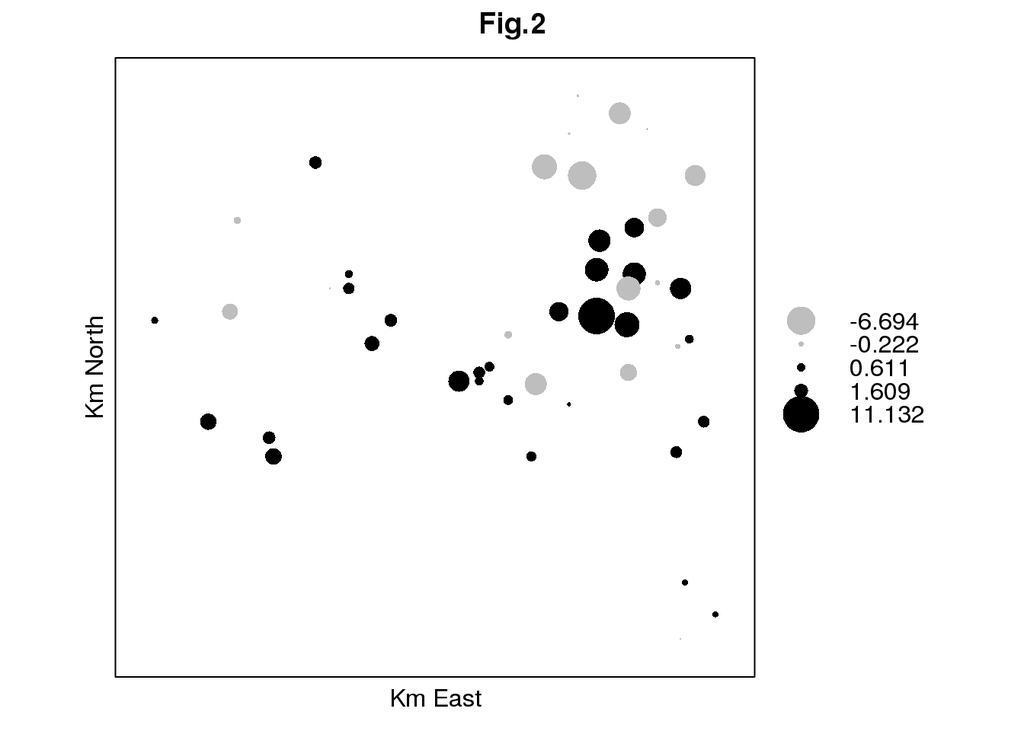

```r
# fig.2
## dataframe
spI <- maptools::spCbind(spX, as.data.frame(I_loc))
## bubble plot local Moran's I
bubble(spI, "Ii", fill=TRUE, col=c("grey","black"), main="Fig.2", xlab="Km East", ylab="Km North")
```

```r
## ggplot2 local Moran's I
#library(ggplot2)
#ggplot(data=as.data.frame(spI), aes(x=Easting..km., y=Northing..km.)) + geom_point(aes(colour=Ii, size=abs(Ii))) + scale_colour_gradient2(midpoint=0) + scale_radius() + coord_fixed(ratio=1) + theme_bw() + xlab("Km East") + ylab("Km North") + ggtitle("Fig.2")
```

> Many of these scores identify neighborhoods composed of sites where elites erected monuments well into the 9th century AD. However, some positive Ii scores identify neigborhoods composed of sites with early terminal monument dates. One must consult a target’s Gi result to distinguish between these two possibilities; positive Gi scores are indicative of the former and negative Gi scores signify the latter. (Premo 2004)

> […] in case of both positive and negative Ii scores, local Moran’s Ii alone provide no additional information that can be used to judge which of the alternative interpretations is most accurate. […] Gi also must be considered. (Premo 2004)

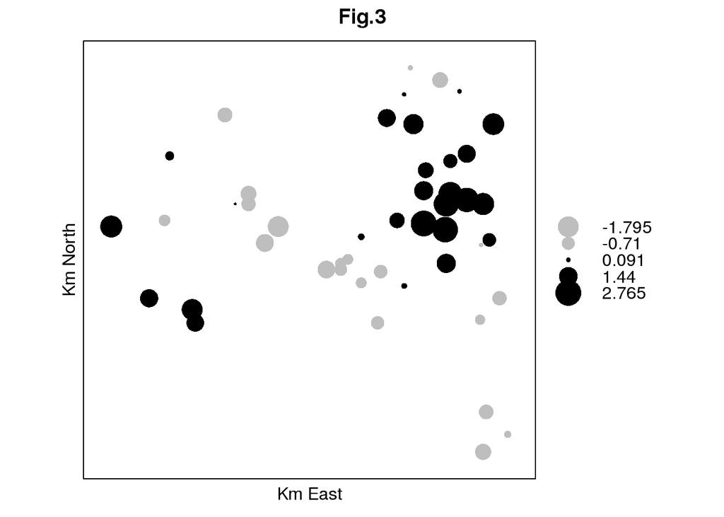

```r
# fig.3
## dataframe
spG <- 0
for (i in 1:47){
  spG[i] <- G_loc[i]
}
spG <- maptools::spCbind(spX, spG)
## bubble plot local Getis's G
bubble(spG, "spG", fill=TRUE, col=c("grey","black"), main="Fig.3", xlab="Km East", ylab="Km North")
```

```r
## ggplot2 local Getis's G
#ggplot(data=as.data.frame(spG), aes(x=Easting..km., y=Northing..km.)) + geom_point(aes(colour=spG, size=abs(spG))) + scale_colour_gradient2(midpoint=0) + scale_radius() + coord_fixed(ratio=1) + theme_bw() + xlab("Km East") + ylab("Km North") + ggtitle("Fig.3")
```

> Fig.3 presents standardized Gi scores at a lag distance of 75 km. In this context positive scores are indicative of neighborhoods composed (mostly) of sites possessing late terminal long-count dates, and scores near zero identify neighborhoods whose terminal long-count dates when summed are intermediate by comparison. (Premo 2004)

## References

Anselin, Luc. 1995. “Local Indicators of Spatial Autocorrelation - Lisa.” *Geographical Analysis* 27: 93–115.

Bivand, R., E.J. Pebesma, and V.G. Rubio. 2008. *Applied Spatial Data Analysis with R*. Use R! Springer. http://books.google.it/books?id=4gg8yx\_lcj0C.

Bove, Frederick J. 1981. “Trend Surface Analysis and the Lowland Classic Maya Collapse.” *American Antiquity* 46 (1): 93–112. doi:10.2307/279989.

Cardillo, Marcelo, Karen Borrazzo, and Judith Charlin. 2016. “Environment, Space, and Morphological Variation of Projectile Points in Patagonia (Southern South America).” *Quaternary International* 422: 44–56. doi:http://dx.doi.org/10.1016/j.quaint.2015.11.134.

Dale, M.R.T., and M.J. Fortin. 2014. *Spatial Analysis: A Guide for Ecologists*. Second Edition. Cambridge University Press.

Getis, A., and J.K. Ord. 1992. “The Analysis of Spatial Association by Use of Distance Statistics.” *Geographical Analysis* 24: 189–206.

Kvamme, Kenneth L. 1990. “Spatial Autocorrelation and the Classic Maya Collapse Revisited: Refined Techniques and New Conclusions.” *Journal of Archaeological Science* 17 (2): 197–207. doi:http://dx.doi.org/10.1016/0305-4403(90)90059-E.

Neiman, F. D. 1997. “Conspicuous Consumption as Wasteful Advertising: A Darwinian Perspective on Spatial Patterns in Clclassic Maya Terminal Monument Dates.” In *Rediscovering Darwin: Evolutionary Theory and Archaeological Explanation*, edited by C. Barton and G. Clark, 7:267–90. Archaeological Papers of the American Anthropological Association. American Anthropological Association.

Premo, L.S. 2004. “Local Spatial Autocorrelation Statistics Quantify Multi-Scale Patterns in Distributional Data: An Example from the Maya Lowlands.” *Journal of Archaeological Science* 31 (7): 855–66. doi:http://dx.doi.org/10.1016/j.jas.2003.12.002.

Whitley, David S., and William A.V. Clark. 1985. “Spatial Autocorrelation Tests and the Classic Maya Collapse: Methods and Inferences.” *Journal of Archaeological Science* 12 (5): 377–95. doi:http://dx.doi.org/10.1016/0305-4403(85)90066-4.

Williams, Jeff T. 1993. “Spatial Autocorrelation and the Classic Maya Collapse: One Technique, One Conclusion.” *Journal of Archaeological Science* 20 (6): 705–9. doi:http://dx.doi.org/10.1006/jasc.1993.1044.